# EDA Zusammenfassung LE2: Data Preparation

# Data Wrangling

EDA fokussiert speziell auf die Transformation von Data Frames Geeignet hierfür ist dplyr da: - Schnell - Direkte Verbindung und Analyse innerhalb externen Datenbanken - Übersichtlich durch Verkettung von Funktionen - Syntaktische Einfachheit

Alternativen sind z.B. data.table, Base R Weiter Ressourcen zu dplyr: https://r4ds.had.co.nz/transform.html Dplyr Cheatsheet: https://rstudio.com/wp-content/uploads/2015/02/data-wrangling-cheatsheet.pdf

```r
# Paket laden
library(dplyr)
```

- Ähnlichkeit mit SQL
- Verküpfung mit %>%

die wichtigsten Funktionalitäten - filter() und select(): Zeilen und spalten selektieren - mutate(): neue Variablen erzeugen - summarise(): Statistiken erzeugen - group_by(): Daten zusammenfassen - bind_rows() und bind_cols(): Datensätze kombinieren - *_join(): relationale Datensätze kombinieren - pivot_long() und pivot_wide(): Daten-Layout verändern

## filter()

Daten mit einer Bedingung auswählen

Syntax: filter(meine_daten, meine_bedingung) Beispiel: filter(iris, Sepal.Length > 7) Alternative iris[iris$Sepal.Lenght >7, ]

Verwandte Funktionen - distinct() - slice_head(), slice_tail(), slice_min(), slice_max() - slice_sample(), sample_n(), sample_frac() - arrange()

## select()

Variablen via Namens auswählen

Syntax: (meine_daten, meine_variablen) Beispiel: select(iris, Sepal.Length, Species) Alternative: iris[, c(“Sepal.Length”, “Species”)]

Verwandte Funktionen - select(…, contains()) - select(…, starts_with()), select(…, ends_with()) - select(…, column_A:column_B) - select(…, -column_A) - relocate()

## mutate()

Neue Variabel aus bestehenden berechen

- Syntax: mutate(meine_Daten, neue_Variable = …)
- Beispiel: mutate(iris, Sepal_l2w = Sepal.Length/Sepal.Width)
- Alternative: iris$Sepal_l2w <- iris$Sepal.Length/iris$Sepal.Width

# summarise()

Neue statistische Kennzahlen aus bestehenden Variaben berehcnen

- Syntax: summarise(meine_daten, neue_statistk = function(…))
- Beispiel: summarise(iris, mean_SL = mean(Sepal.Lenght), medial_SL = median(Sepal.Lenght))
- Alternative: mean_SL <- mean(iris$Sepal.Lenght) und median_SL <- median(iris$Sepal.Lenght)

# group_by()

Gruppierte Kopie der Daten

- Syntax: group_by(meine_Daten, kategoriale_Variable)
- Beispiel: group_by(iris, Species)
- Alternative: by(iris, INDICES = …)

Der grösste Nutzen liegt in der Verkettung von Gruppierungen mit Erzeugung neuer Variablen (mutate) oder statistischer Kennzahlen (summarise) via Pipes (%>%)

Beispiel 1: iris %>% group_by(Species) %>% summarise(n_obs = n(), mean_l = mean(Sepal.Length)) %>% ungroup()

Beispiel 2: iris %>% group_by(Species) %>% mutate(Petal.Width.centered = Petal.Width - mean(Petal.Width)) %>% ungroup()

Es wird empfohlen zum Schluss ungroup() einzusetzen, damit keine unerwünschten Effekte in Folgeanalysen auftauchen.

```r
# Lade Beispieldaten
avengers <- read.csv('data/avengers.csv')
superheros <- read.csv('data/superheros.csv')
publisher <- read.csv('data/publisher.csv')
```

```
incomplete final line found by readTableHeader on 'data/publisher.csv'
```

```r
avengers
```

| name | alignment | gender | publisher |
| --- | --- | --- | --- |
| Magento | bad | male | Marvel |
| Storm | good | female | Marvel |
| Mystique | bad | female | Marvel |
| Batman | good | male | DC |
| Joker | bad | male | DC |
| Catwomen | bad | female | DC |
| Hellboy | good | male | Dar Horse Comics |

```r
superheros
```

| name | alignment | gender | publisher |
| --- | --- | --- | --- |
| Thor | good | male | Marvel |
| Iron Man | good | male | Marvel |
| Hulk | good | male | Marvel |
| Hawkeye | good | male | Marvel |
| Black Widow | good | female | Marvel |
| Captain America | good | male | Marvel |
| Magento | bad | male | Marvel |

```r
publisher
```

| publisher | yr_founded |
| --- | --- |
| DC | 1934 |
| Marvel | 1939 |
| Image | 1992 |

# bind_rows() / bind_cols()

Kombinieren von Dataframes

Syntax: bind_rows(meine_Daten, meine_Daten2) Beispiel: bind_rows(avengers, superheros)

Syntax: bind_cols(meine_Daten, meine_Daten2) Beispiel: bind_cols(avengers, superheros)

bind_rows() kombiniert Zeilen von x und y sequenziell, wobie übereinstimmende Beobachtungen in x und y zu Duplikatoine führt. Spalten werden nach Namen abgeglichen, fehlende Spalten nach NA befüllt.

bind_cols() gleicht Zeilen nach Position ab, d.h. die Datensätze müssen die gleiche Anzahl von Zeilen haben

```r
bind_rows(avengers,superheros)
```

[output not shown]

| name | alignment | gender | publisher |
| --- | --- | --- | --- |
| Magento | bad | male | Marvel |
| Storm | good | female | Marvel |
| Mystique | bad | female | Marvel |
| Batman | good | male | DC |
| Joker | bad | male | DC |
| Catwomen | bad | female | DC |
| Hellboy | good | male | Dar Horse Comics |
| Thor | good | male | Marvel |
| Iron Man | good | male | Marvel |
| Hulk | good | male | Marvel |

[output cut: 4 more lines]

```r
# Magento ist nun zweimal vorhanden

bind_cols(avengers,superheros)
```

| name | alignment | gender | publisher | name1 | alignment1 | gender1 | publisher1 |
| --- | --- | --- | --- | --- | --- | --- | --- |
| Magento | bad | male | Marvel | Thor | good | male | Marvel |
| Storm | good | female | Marvel | Iron Man | good | male | Marvel |
| Mystique | bad | female | Marvel | Hulk | good | male | Marvel |
| Batman | good | male | DC | Hawkeye | good | male | Marvel |
| Joker | bad | male | DC | Black Widow | good | female | Marvel |
| Catwomen | bad | female | DC | Captain America | good | male | Marvel |
| Hellboy | good | male | Dar Horse Comics | Magento | bad | male | Marvel |

# union() / intersect() / setdiff()

Syntax: union(meine_Daten, meine_Daten2) Beispiel: union(avengers, superheros)

Syntax: intersect(meine_Daten, meine_Daten2) Beispiel: intersect(avengers, superheros)

union() analog bind_rows(), Duplikate werden aber entfernt intersect() schnittmenge der Daten, Duplikate werden entfernt

```r
union(avengers, superheros)
```

```
Column `name` joining factors with different levels, coercing to character vectorColumn `publisher` joining factors with different levels, coercing to character vector
```

| name | alignment | gender | publisher |
| --- | --- | --- | --- |
| Magento | bad | male | Marvel |
| Storm | good | female | Marvel |
| Mystique | bad | female | Marvel |
| Batman | good | male | DC |
| Joker | bad | male | DC |
| Catwomen | bad | female | DC |
| Hellboy | good | male | Dar Horse Comics |
| Thor | good | male | Marvel |
| Iron Man | good | male | Marvel |
| Hulk | good | male | Marvel |

[output cut: 3 more lines]

```r
# Magento ist nur noch einmal vorhanden

intersect(avengers, superheros)
```

```
Column `name` joining factors with different levels, coercing to character vectorColumn `publisher` joining factors with different levels, coercing to character vector
```

| name | alignment | gender | publisher |
| --- | --- | --- | --- |
| Magento | bad | male | Marvel |

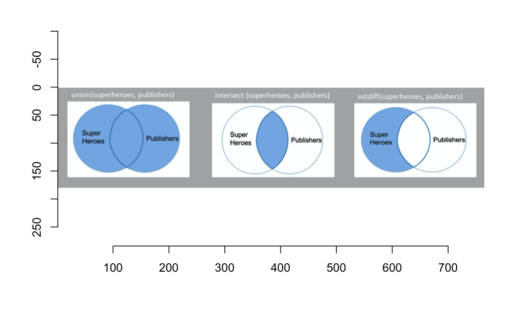

```r
library(imager)

# Mengenoperationen
load.image('data/union_intersect.png') %>% plot
```

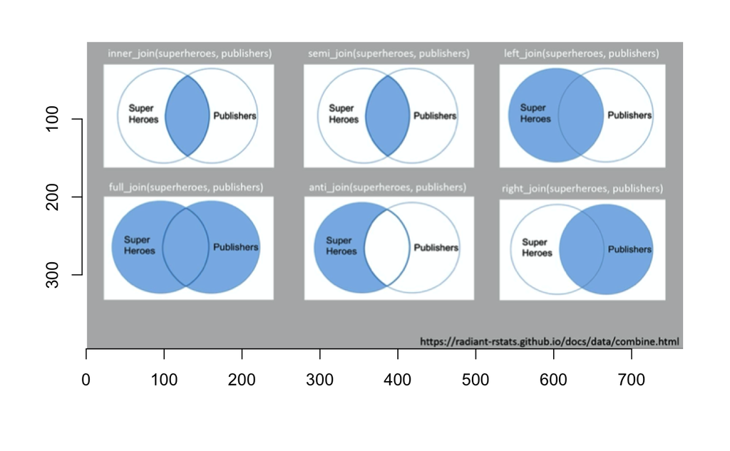

```r
#Joins
load.image('data/joins.png') %>% plot
```

# inner_join() / semi_join()

Syntax: inner_join(meine_Daten, meine_Daten2, key=“key”) Syntax: semi_join(meine_Daten, meine_Daten2, key=“key”)

Kombination von Daten anhand eines Schlüsselattributs (key)

inner_join() gibt alle Zeilen von x und y mit übereinstimmenden Key zurück. Bei mehrere Übereinstimmungen werden alle Kombinationen zurückgegeben.

semi_join() gibt nur Spalten aus x zurück & dupliziert nie Zeilen von x

```r
inner_join(avengers,publisher,key='publisher')
```

```
Column `publisher` joining factors with different levels, coercing to character vector
```

| name | alignment | gender | publisher | yr_founded |
| --- | --- | --- | --- | --- |
| Magento | bad | male | Marvel | 1939 |
| Storm | good | female | Marvel | 1939 |
| Mystique | bad | female | Marvel | 1939 |
| Batman | good | male | DC | 1934 |
| Joker | bad | male | DC | 1934 |
| Catwomen | bad | female | DC | 1934 |

```r
semi_join(avengers,publisher,key='publisher')
```

```
Column `publisher` joining factors with different levels, coercing to character vector
```

| name | alignment | gender | publisher |
| --- | --- | --- | --- |
| Magento | bad | male | Marvel |
| Storm | good | female | Marvel |
| Mystique | bad | female | Marvel |
| Batman | good | male | DC |
| Joker | bad | male | DC |
| Catwomen | bad | female | DC |

# full_join() / anti_join()

Syntax: full_join(meine_Daten, meine_Daten2, key=“key”) Syntax: anti_join(meine_Daten, meine_Daten2, key=“key”)

full_join() gibt alle Zeilen und Spalten zurück anti_join() gibt alle Zeilen von x ohne übereinstimmende Werte in y zurück und liefert nur Spalten von x

```r
full_join(avengers,publisher,key='publisher')
```

```
Column `publisher` joining factors with different levels, coercing to character vector
```

| name | alignment | gender | publisher | yr_founded |
| --- | --- | --- | --- | --- |
| Magento | bad | male | Marvel | 1939 |
| Storm | good | female | Marvel | 1939 |
| Mystique | bad | female | Marvel | 1939 |
| Batman | good | male | DC | 1934 |
| Joker | bad | male | DC | 1934 |
| Catwomen | bad | female | DC | 1934 |
| Hellboy | good | male | Dar Horse Comics | NA |
| NA | NA | NA | Image | 1992 |

```r
anti_join(avengers,publisher,key='publisher')
```

```
Column `publisher` joining factors with different levels, coercing to character vector
```

| name | alignment | gender | publisher |
| --- | --- | --- | --- |
| Hellboy | good | male | Dar Horse Comics |

# left_join() / right_join()

Syntax: left_join(meine_Daten, meine_Daten2, key=“key”) Syntax: right_join(meine_Daten, meine_Daten2, key=“key”)

left_join() alle Zeilen von x und alle Spalten von x und y right_join() gerade umgekehrt

# Tidy Data

Das Prinzip ordentlicher Datenhaltung:

1. Jede Variable hat eine eigene Spalte
2. Jede Beobachtung hat eine eigene Zeile
3. Jeder Wert hat eine eigene Zelle

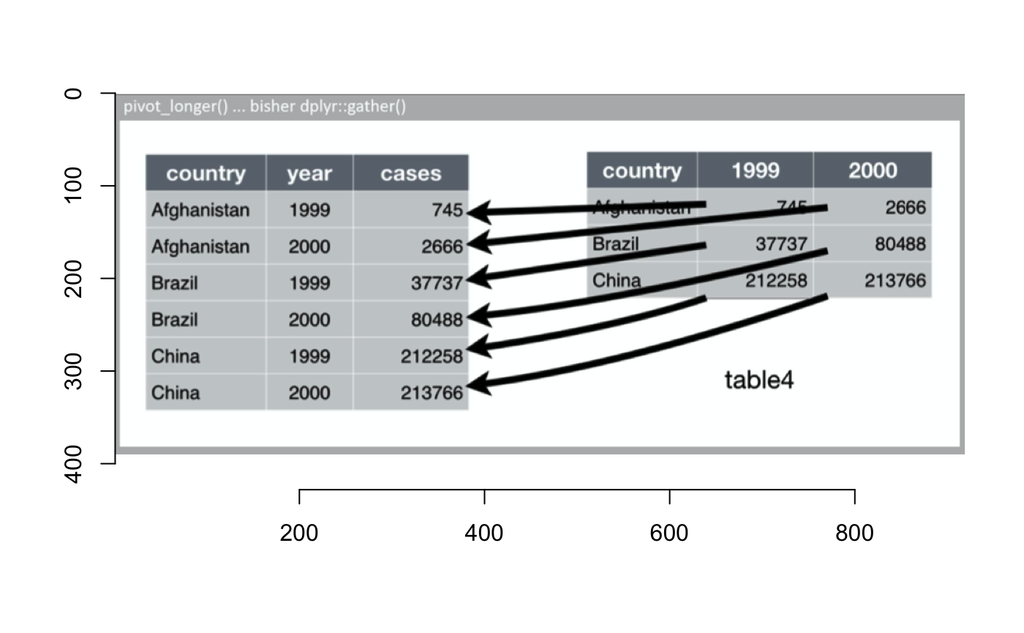

```r
load.image('data/tidydata.png') %>% plot
```

# pivot_wider() / pivot_longer()

Syntax: pivot_wider(meine_Daten, names_from = Beziechnung_Messung, values_from = Wert_Messung) Syntax: pivot_longer(meine_Daten, cols = meine_Pivotspalten, names_to = Bezeichung_Messung, values_to = Wert_Messung)

pivot_wider() wird verwendet um Ordnung in Daten zu bringen, in denen eine Beobachtung über mehrere Zeilen verteilt ist.

pivot_longer() wird verwendet um Ordnung in Daten zu bringen, in denen eine Beobachtung über mehrere Spalten verteilt ist